# Project_prosperLoanData_Part1

```python
# import all packages and set plots to be embedded inline
import numpy as np
import pandas as pd
import matplotlib.pyplot as plt
import seaborn as sb

%matplotlib inline
```

```python
# load in the dataset into a pandas dataframe, print statistics
df = pd.read_csv('prosperLoanData.csv')
```

```python
# high-level overview of data shape and composition
print(df.shape)
print(df.dtypes)
print(df.head(10))
```

```
(113937, 81)
ListingKey                      object
ListingNumber                    int64
ListingCreationDate             object
CreditGrade                     object
Term                             int64
                                ...
PercentFunded                  float64
Recommendations                  int64
InvestmentFromFriendsCount       int64
InvestmentFromFriendsAmount    float64
Investors                        int64
Length: 81, dtype: object
                ListingKey  ListingNumber            ListingCreationDate  \
0  1021339766868145413AB3B         193129  2007-08-26 19:09:29.263000000
```

[output cut: 71 more lines]

```python
df.info()
```

```
<class 'pandas.core.frame.DataFrame'>
RangeIndex: 113937 entries, 0 to 113936
Data columns (total 81 columns):
 #   Column                               Non-Null Count   Dtype
---  ------                               --------------   -----
 0   ListingKey                           113937 non-null  object
 1   ListingNumber                        113937 non-null  int64
 2   ListingCreationDate                  113937 non-null  object
 3   CreditGrade                          28953 non-null   object
 4   Term                                 113937 non-null  int64
 5   LoanStatus                           113937 non-null  object
 6   ClosedDate                           55089 non-null   object
 7   BorrowerAPR                          113912 non-null  float64
 8   BorrowerRate                         113937 non-null  float64
 9   LenderYield                          113937 non-null  float64
```

[output cut: 73 more lines]

```python
#selecting features of interest from dataframe
features = ['EmploymentStatus', 'LoanStatus', 'BorrowerAPR', 'IncomeRange', 'CreditGrade', 'Investors']
df_subset = df[features]
```

```python
df_subset.head()
```

|  | EmploymentStatus | LoanStatus | BorrowerAPR | IncomeRange | CreditGrade | Investors |
| --- | --- | --- | --- | --- | --- | --- |
| 0 | Self-employed | Completed | 0.16516 | $25,000-49,999 | C | 258 |
| 1 | Employed | Current | 0.12016 | $50,000-74,999 | NaN | 1 |
| 2 | Not available | Completed | 0.28269 | Not displayed | HR | 41 |
| 3 | Employed | Current | 0.12528 | $25,000-49,999 | NaN | 158 |
| 4 | Employed | Current | 0.24614 | $100,000+ | NaN | 20 |

```python
df_subset.describe()
```

|  | BorrowerAPR | Investors |
| --- | --- | --- |
| count | 113912.000000 | 113937.000000 |
| mean | 0.218828 | 80.475228 |
| std | 0.080364 | 103.239020 |
| min | 0.006530 | 1.000000 |
| 25% | 0.156290 | 2.000000 |
| 50% | 0.209760 | 44.000000 |
| 75% | 0.283810 | 115.000000 |
| max | 0.512290 | 1189.000000 |

```python
df_subset = df_subset[~df_subset.BorrowerAPR.isna()]
df_subset = df_subset[~df_subset.CreditGrade.isna()]
```

#### What is the structure of your dataset? </br>

The dataset contains 113,937 loans with 81 features including (EmploymentStatus, LoanStatus, BorrowerAPR, IncomeRange, CreditGrade, Investors and many others features)</br>

#### What is/are the main feature(s) of interest in your dataset? </br>

I'm most interested in figureing out what features are best for predicting the Investors for the loan.</br>

#### What features in the dataset do you think will help support your investigation into your feature(s) of interest?</br>

I expect that the total loan amount will have a positive effect on the Investors. I also think that the EmploymentStatus, LoanStatus, BorrowerAPR, IncomeRange, CreditGrade will also have effects on the Investors.</br>

## Univariate Exploration </br>

I'll start by looking at the distribution of the main variable of interest: Investors.</br>

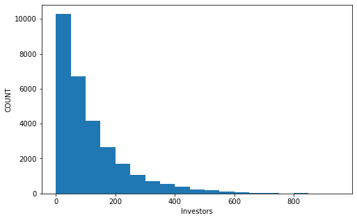

```python
bins = np.arange( 0, df_subset['Investors'].max()+50, 50)

plt.figure(figsize=[8, 5])
plt.hist(data = df_subset, x = 'Investors', bins = bins)
plt.xlabel('Investors')
plt.ylabel('COUNT')
plt.show()
```

##### The distribution of Investors looks a right-skewed : A large peak centered at 0 - 200. Only very few loans have Investors greater than 600.

#### Next up, the first predictor variable of interest: BorrowerAPR.

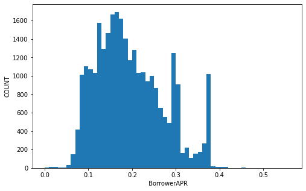

```python
binsize = 0.05
bins = np.arange(0, df_subset['BorrowerAPR'].max()+binsize, 0.01)

plt.figure(figsize=[8, 5])
plt.hist(data = df_subset, x = 'BorrowerAPR', bins = bins)
plt.xlabel(' BorrowerAPR')
plt.ylabel('COUNT')
plt.show()
```

#### The BorrowerAPR has A random distribution looks, a large peak centered at 0.1 - 0.2.

#### Now, look at the distributions of other variables of interest: IncomeRange

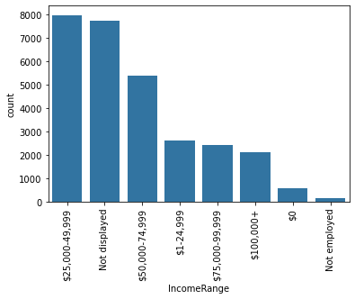

```python
IR_order = df_subset['IncomeRange'].value_counts().index
base_color = sb.color_palette()[0]
sb.countplot(data = df_subset, x = 'IncomeRange', color = base_color, order = IR_order)
plt.xticks(rotation =90)
plt.show()
```

##### I'll now move on to the others variables in the dataset: LoanStatus, CreditGrade, EmploymentStatus.

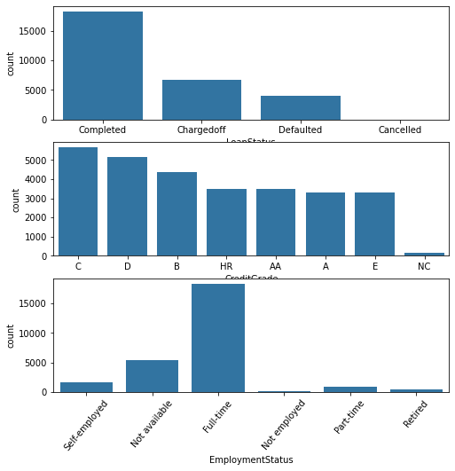

```python
CG_order = df_subset['CreditGrade'].value_counts().index
fig, ax = plt.subplots(nrows=3, figsize = [8,8])

sb.countplot(data = df_subset, x = 'LoanStatus', color = base_color, ax = ax[0])
sb.countplot(data = df_subset, x = 'CreditGrade', color = base_color, order = CG_order, ax = ax[1])
sb.countplot(data = df_subset, x = 'EmploymentStatus', color = base_color, ax = ax[2])

plt.xticks(rotation=50);
plt.show()
```

#### The most of the Loan Status are completed. The CreditGrade of most of the loans are C then D. Most of borrowers are employed and full-time.

#### Discuss the distribution(s) of your variable(s) of interest. Were there any unusual points? Did you need to perform any transformations?

The distribution of Investors looks a right-skewed : A large peak centered at 0 - 200. There are no unusual points and no need to perform any transformations.

#### Of the features you investigated, were there any unusual distributions? Did you perform any operations on the data to tidy, adjust, or change the form of the data? If so, why did you do this?

There is no need to perform any transformations.

## Bivariate Exploration

To start off with, I want to look at the pairwise correlations present between features in the data.

```python
numeric_vars = ['BorrowerAPR', 'Investors']
categoric_vars = ['LoanStatus', 'CreditGrade', 'EmploymentStatus', 'IncomeRange']
```

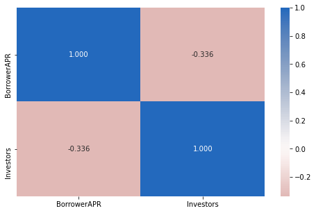

```python
plt.figure(figsize = [8, 5])
sb.heatmap(df_subset[numeric_vars].corr(), annot = True, fmt = '.3f',
           cmap = 'vlag_r', center = 0)
plt.show()
```

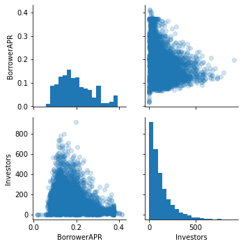

```python
# plot matrix: sample 500 diamonds so that plots are clearer and
# they render faster

df_samp = df_subset.sample(5000)
g = sb.PairGrid(data = df_samp.dropna(), vars = numeric_vars)
g = g.map_diag(plt.hist, bins=20)
g.map_offdiag(plt.scatter, alpha=0.2);
```

#### The correlation coefficient of borrower APR and Investors amount is -0.336, the scatter plot also shows that these two variables are negatively correlated, that is the more the Investors, the lower the APR.

#### Let's move on to looking at how borrower APR and Investors correlate with the categorical variables.

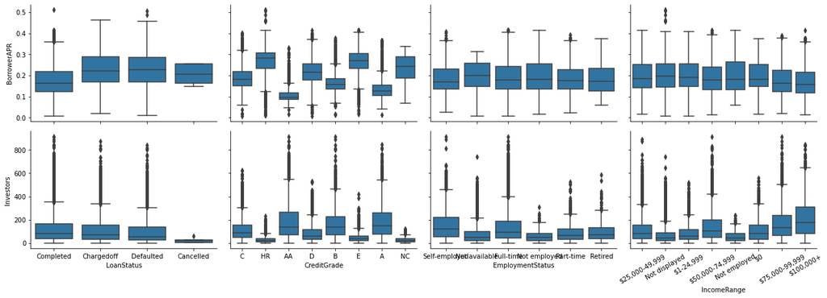

```python
def boxgrid(x, y, **kwargs):
    """ Quick hack for creating box plots with seaborn's PairGrid. """
    default_color = sb.color_palette()[0]
    sb.boxplot(x, y, color = default_color)

plt.figure(figsize = [10 , 10])
g = sb.PairGrid(data = df_subset, y_vars = ['BorrowerAPR', 'Investors'],
                x_vars = categoric_vars, size = 3, aspect = 1.5)

g.map(boxgrid);
plt.xticks(rotation=30);
```

#### Finally, let's look at relationships between the four categorical features.

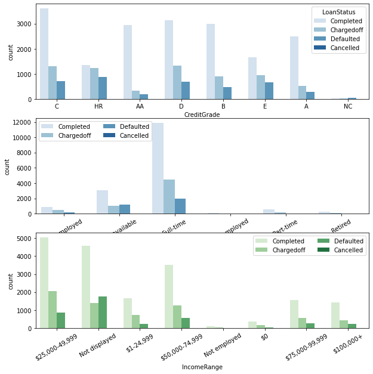

```python
plt.figure(figsize = [10, 10])

# subplot 1: CreditGrade vs LoanStatus
plt.subplot(3, 1, 1)
sb.countplot(data = df_subset, x = 'CreditGrade', hue = 'LoanStatus', palette = 'Blues')

# subplot 2: EmploymentStatus vs. LoanStatus
ax = plt.subplot(3, 1, 2)
sb.countplot(data = df_subset, x = 'EmploymentStatus', hue = 'LoanStatus', palette = 'Blues')
ax.legend(ncol = 2)
plt.xticks(rotation=30);

# subplot 3: IncomeRange vs. LoanStatus, use different color palette
ax = plt.subplot(3, 1, 3)
sb.countplot(data = df_subset, x = 'IncomeRange', hue = 'LoanStatus', palette = 'Greens')
ax.legend(loc = 1, ncol = 2)
plt.xticks(rotation=30);


plt.show()
```

[output not shown]

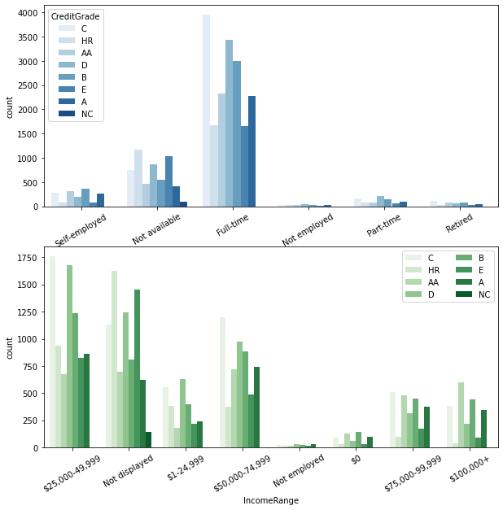

```python
plt.figure(figsize = [10, 10])

# subplot 4: EmploymentStatus vs. CreditGrade
ax = plt.subplot(2, 1, 1)
sb.countplot(data = df_subset, x = 'EmploymentStatus', hue = 'CreditGrade', palette = 'Blues')
#ax.legend(ncol = 2)
plt.xticks(rotation=30);


# subplot 5: IncomeRange vs. CreditGrade
ax = plt.subplot(2, 1, 2)
sb.countplot(data = df_subset, x = 'IncomeRange', hue = 'CreditGrade', palette = 'Greens')
ax.legend(ncol = 2)
plt.xticks(rotation=30);
```

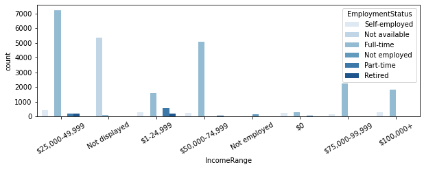

```python
plt.figure(figsize = [10 ,3])
# subplot 6: IncomeRange vs. EmploymentStatus
ax = plt.subplot(1, 1, 1)
sb.countplot(data = df_subset, x = 'IncomeRange', hue = 'EmploymentStatus', palette = 'Blues')
plt.xticks(rotation=30);
```

#### The above graphic does not show that there is a clear relationship between (IncomeRange) and (EmploymentStatus).

#### With the preliminary look at bivariate relationships out of the way, I want to see how borrower APR and Investors are related to one another for all of the data.

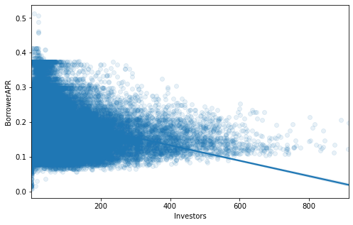

```python
plt.figure(figsize = [8, 5])
sb.regplot(data = df_subset, x = 'Investors', y = 'BorrowerAPR', scatter_kws={'alpha':1/10});
```

#### This plot shows that at different size for investors, the APR has a large range, but the APR range decreases as investors increase. In general, the borrower's APR is negatively correlated with the investors.

#### Talk about some of the relationships you observed in this part of the investigation. How did the feature(s) of interest vary with other features in the dataset?

The borrower APR is negatively associated with the Investors, which mean the more the Investors, the lower the APR.

## Multivariate Exploration

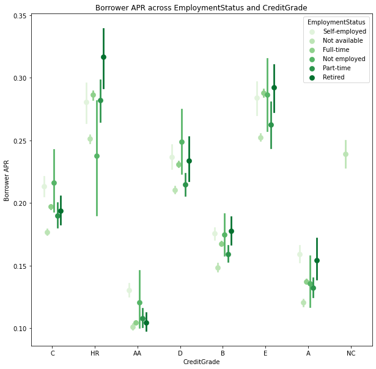

```python
fig = plt.figure(figsize = [10,10])

ax = sb.pointplot(data = df_subset, x = 'CreditGrade', y = 'BorrowerAPR', hue = 'EmploymentStatus',
           palette = 'Greens', linestyles = '', dodge = 0.4)
plt.title('Borrower APR across EmploymentStatus and CreditGrade')
plt.ylabel('Borrower APR')

ax.set_yticklabels([],minor = True);
```

#### Here we see that the borrower's APR of class HR (CreditGrade) for retired employees is increasing, while the borrower's APR of class AA and class A (CreditGrade) is decreasing.

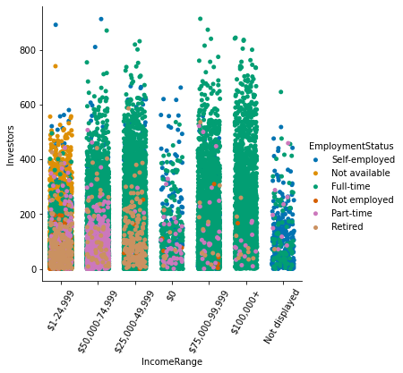

```python
g = sb.FacetGrid(data = df_subset, hue = 'EmploymentStatus', size = 5,
                 palette = 'colorblind')
g.map(sb.stripplot, 'IncomeRange', 'Investors', dodge=True, jitter=0.3)
g.add_legend()
plt.xticks(rotation=60);
```

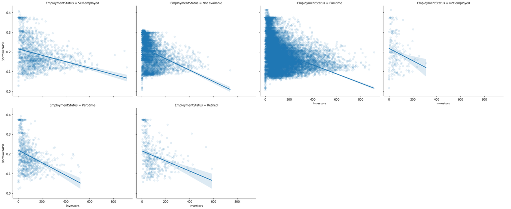

```python
# EmploymentStatus effect on relationship of APR and Investors
g=sb.FacetGrid(data=df_subset, aspect=1.2, height=5, col='EmploymentStatus', col_wrap=4)
g.map(sb.regplot, 'Investors', 'BorrowerAPR', x_jitter=0.04, scatter_kws={'alpha':0.1});
g.add_legend();
```

#### Talk about some of the relationships you observed in this part of the investigation. Were there features that strengthened each other in terms of looking at your feature(s) of interest?

I have tried to explore the relationship between EmploymentStatus and CreditGrade and how they relate to the increase or decrease of the borrower's APR, and I have noticed that if the variable is HR or E, the rate increases significantly.

#### Were there any interesting or surprising interactions between features?

I noticed that the borrower's APR of class AA and A(CreditGrade) are decreasing for almost all (EmploymentStatus) classes.